# Implementation of Girvan-Newman Algorithm from scratch for Graph analysis in R

##### *Jungsik Noh*

Girvan-Newman Algorithm is for community detection in a network, that is, a graph. Its implementation first starts with Breadth First Search (BFS) to find minimum spanning trees in a graph. Then we can compute the edge betweenness which is the number of the shortest paths going through a given edge, as a measure of centrality of an edge in a graph. By successively removing the edges with the highest betweenness, the algorithm detects communities which are disconnected components.

### Load packages

To visualize an example graph, *igraph* package is utilized.

```r
library(igraph)
```

### Girvan-Newman algorithm from scratch

Implementation contains the following six functions.

- *BFS_unweightedGraph(Gmat, src)*
  - Find minimum spanning trees from a source node (src) for a given unweighted graph (Gmat)
- *BFS_unweightedGraph_getPaths(BFSout, src, dest)*
  - Extract the shortest paths (src -> dest) from a BFS output
- *getEdges(Gmat)*
  - Get edges from a given adjacency matrix
- *myEdgeBetweenness(Gadjmat)*
  - Compute edge betweennesses for all the edges
- *isConnected(Gadjmat)*
  - Check if all nodes in a graph are connected or not
- *GirvanNewman1step(Gmat)*
  - Find and remove an edge having the highest edge betweenness

```r
BFS_unweightedGraph <- function(Gmat, src){
  # Dijkstra type algorithm to find shortest paths from a source node for
  # unweighted graphs
  # output: shDist, nPaths, prevVertexList (list)
  # internal control var: visited, queue

  # setup param
  n = nrow(Gmat)                # total num of vertexes
  visited = rep(FALSE, n)       # visited indicator to setup a queue (default=F)
  queue = numeric()             # queue for BFS
  shDist = rep(Inf, n)          # shortest distances from the src
  nPaths = rep(0, n)            # num of shortest paths from the src
  prevVertexList = vector("list", length = n)   # shortest paths will be stored

  # at the src vertex
  shDist[src] = 0
  nPaths[src] = 1
  visited[src] = TRUE
  queue = c(queue, src)
  prevVertexList[[src]] = -1      # -1 means it is the src
                                  # a list due to possible multiplicity

  # BFS type algorithm
  while(length(queue) != 0){
    curr = queue[1]             # get a current vertex from queue
    queue = queue[-1]           # remove curr from queue (FIFO)

    # For all connected vertexes
    for (u in which(Gmat[curr, ] == 1)){
      # If u is not visited, push it to the queue
      if (!visited[u]){
        visited[u] = TRUE
        queue = c(queue, u)
      }
      # print(queue)

      # Check if it is a better path
      if (shDist[u] > shDist[curr] + 1){
        shDist[u] = shDist[curr] + 1
        nPaths[u] = nPaths[curr]
        prevVertexList[[u]] = curr
      } else if (shDist[u] == shDist[curr] + 1){
        # Check if additional shortest path is found
        nPaths[u] = nPaths[curr] + 1
        prevVertexList[[u]] = c(prevVertexList[[u]], curr)
      }
    }
  }

  result = list(numVertexes=n,
                source=src,
                shDist=shDist,
                nPaths=nPaths,
                prevVertexList=prevVertexList)
  return(result)
}
```

```r
BFS_unweightedGraph_getPaths <- function(BFSout, src, dest){
  # Extract the shortest paths (src -> dest) from a BFS output for a Graph and the src
  n = BFSout$numVertexes
  tmp = BFSout$source
  if (tmp != src){
    print("The source of BFSout is different from the input src. Check the sanity of input.")
    return()
  }

  prevVertexList = BFSout$prevVertexList
  numPaths = BFSout$nPaths[dest]
  listPaths = vector('list', numPaths)
  listPathsInd = 1

  # Backtracking
  # Initialize
  q_branching = numeric()     # queue for vertexes with multiple prevVertexes (LIFO)
  q_newBranch = numeric()     # additional prevVertexes at q_branching
  q_pastPath = list()         # path up to the last q_branching
  currPath = numeric()

  curr = dest                    # current vertex
  tmp = prevVertexList[[curr]]
  tmp = tmp[length(tmp):1]
  crawl = tmp[length(tmp)]
  crawlRight = tmp[-length(tmp)]
  q_branching = c( q_branching, rep(curr, length(crawlRight)) )
  q_newBranch = c(q_newBranch, crawlRight)
  currPath = c(currPath, curr)
  if (length(crawlRight) >= 1){
    for (i in 1:length(crawlRight)){
      q_pastPath = c(q_pastPath, currPath)
    }
  }

  # Stopping rule = (crawl = -1 (at the src) and q_branching is empty)
  while( (crawl != -1) || (length(q_branching)!=0) ){

    #print(crawl)
    curr = crawl           # Move to the previous vertex
    tmp = prevVertexList[[curr]]
    tmp = tmp[length(tmp):1]
    crawl = tmp[length(tmp)]
    crawlRight = tmp[-length(tmp)]
    q_branching = c( q_branching, rep(curr, length(crawlRight)) )
    q_newBranch = c(q_newBranch, crawlRight)
    currPath = c(currPath, curr)
    if (length(crawlRight) >= 1){
      for (i in 1:length(crawlRight)){
        q_pastPath = c(q_pastPath, list(currPath))
      }
    }

    # When it reached the src, report one shortest path
    if (crawl == -1){
      # found one shortest path
      listPaths[[listPathsInd]] = currPath[length(currPath):1]
      listPathsInd = listPathsInd + 1

      # Further if branching vertexes remain, go to the last q_branching and remove queues.
      if (length(q_branching)!=0){
        curr = tail(q_branching, 1)                 # go to the last branching vertex
        crawl = tail(q_newBranch, 1)
        currPath = q_pastPath[[length(q_pastPath)]]
        q_branching = q_branching[-length(q_branching)]     # LIFO
        q_newBranch = q_newBranch[-length(q_newBranch)]
        q_pastPath = q_pastPath[-length(q_pastPath)]
      }
    }
  }

  return(listPaths)
}
```

```r
getEdges <- function(Gmat){
  edges = list()
  i <- 1
  n <- nrow(Gmat)
  for (i in 1:n){
    for (j in which(Gmat[i, ] == 1)){
      if (j > i){
        e = list(c(i, j))
        edges = append(edges, e)
      }
    }
  }
  return(edges)
}
```

```r
myEdgeBetweenness <- function(Gadjmat){
  # Initialize var
  n <- nrow(Gadjmat)
  edgeList <- getEdges(Gadjmat)
  nEdges <- length(edgeList)
  edgeBetweenness <- numeric(nEdges)
  nShPathsMat <- matrix(0, n, n)
  nShPathViaAnEdge <- matrix(0, n, n)
  betnnessSummand <- matrix(0, nEdges, n*(n-1)/2)   # May use lots of memory for large n
  BFSout <- list()

  # BFS for each vertex
  for (i in 1:n){
    BFSout[[i]] <- BFS_unweightedGraph(Gadjmat, i)
  }

  # Count the number of the shortest paths between i and j
  for (i in c(1:(n-1))){
    for (j in c((i+1):n)){
      nShPathsMat[i,j] <- BFSout[[i]]$nPaths[j]
    }
  }

  # Compute betnnessSummand
  for (i in c(1:(n-1))){
    for (j in c((i+1):n)){
      # Extract shPaths, which is done only once per pair
      pathij <- BFS_unweightedGraph_getPaths(BFSout[[i]], i, j)

      # Count shPaths going through a give edge
      for (k in 1:nEdges){
        e <- edgeList[[k]]
        count <- 0
        for (l in 1:length(pathij)){
          path_l = pathij[[l]]
          # Check if a path contains the edge e
          for (m in 1:(length(path_l)-1)){
            if (all(path_l[m:(m+1)] == e) | all(path_l[m:(m+1)] == e[2:1])){
              count <- count + 1
            }
          }
        }
        summand <- count / nShPathsMat[i,j]
        # Indexing upper matrix cells in a linear fashion
        betnnessSummand[k, (i-1)*(2*n-i)/2 + (j-i)] <- summand
      }
    }
  }

  # Compute edge betweenness
  edgeBetweenness = rowSums(betnnessSummand)

  # output
  n = length(edgeList)
  edgeMat = matrix(NA, 2, n)
  for (i in 1:n){
    edgeMat[, i] = cbind(edgeList[[i]][1], edgeList[[i]][2])
  }
  out = list(edgeMat=edgeMat, edgeBetweenness=edgeBetweenness)
  return(out)
}
```

```r
isConnected <- function(Gadjmat){
  n <- nrow(Gadjmat)
  BFS1 <- BFS_unweightedGraph(Gadjmat, 1)
  return(!any(BFS1$nPaths == 0))
}
```

```r
GirvanNewman1step <- function(Gmat){
  # Initialize
  n <- nrow(Gmat)

  # Check input matrix
  if (!isConnected(Gmat)){
    print("Input adj matrix is not connected, so it cannot be searched by this function.")
    return()
  }

  edgeList <- getEdges(Gmat)
  edgeBetweenness <- myEdgeBetweenness(Gmat)$edgeBetweenness
  ind <- which.max(edgeBetweenness)
  e <- edgeList[[ind]]
  Gmat2 <- Gmat
  Gmat2[e[1], e[2]] <- 0
  Gmat2[e[2], e[1]] <- 0
  isConnected <- isConnected(Gmat2)

  out <- list(n=n, edgeList=edgeList, edgeBetweenness=edgeBetweenness,
              removedEdge=e, outAdjmat=Gmat2, isConnected=isConnected)
  return(out)
}
```

### Construct/visualize a toy graph

Let’s consider a toy network with 8 nodes which is an unweighted graph.

```r
          #  node  1,2,3,4,5,6,7,8
Gadjmat = rbind( c(0,1,1,0,1,0,0,0),
                 c(1,0,0,1,0,0,0,0),
                 c(1,0,0,0,1,0,0,0),
                 c(0,1,0,0,1,1,0,0),
                 c(1,0,1,1,0,0,0,0),
                 c(0,0,0,1,0,0,1,1),
                 c(0,0,0,0,0,1,0,0),
                 c(0,0,0,0,0,1,0,0) )
```

The *igraph* library gives us nice visualization of graphs.

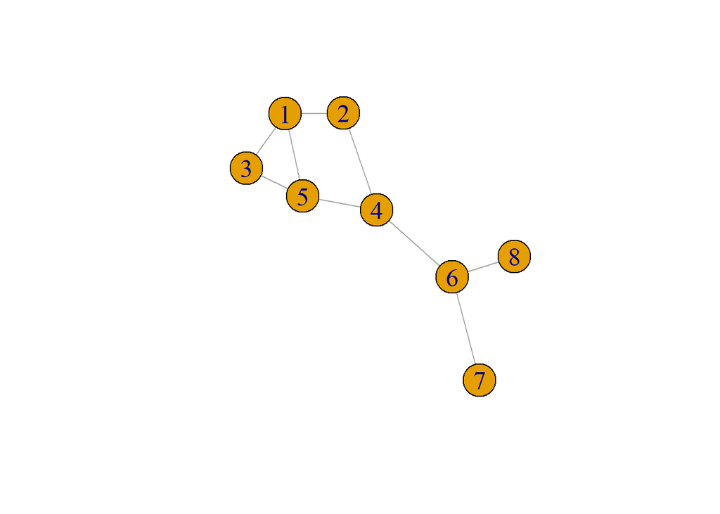

```r
grp1 <- graph_from_adjacency_matrix(Gadjmat, mode="undirected", diag=FALSE)
set.seed(1); plot(grp1, vertex.size=25, vertex.label.cex=1.5)
```

Using the BFS, we can get the shortest paths between all pairs of nodes. Total 33 shortest paths are found.

```r
n = nrow(Gadjmat)
BFSout = vector("list", length=n)
for (i in 1:n){
  BFSout[[i]] <- BFS_unweightedGraph(Gadjmat, i)
}

allPaths = list()
for (src in 1:(n-1)){
  for (dest in c((src+1):n)){
    tmpout = BFS_unweightedGraph_getPaths(BFSout[[src]], src, dest)
    allPaths = append(allPaths, tmpout)
  }
}

allPaths
```

```
## [[1]]
## [1] 1 2
##
## [[2]]
## [1] 1 3
##
## [[3]]
## [1] 1 2 4
##
## [[4]]
## [1] 1 5 4
##
## [[5]]
## [1] 1 5
##
## [[6]]
## [1] 1 2 4 6
##
## [[7]]
## [1] 1 5 4 6
##
## [[8]]
## [1] 1 2 4 6 7
##
## [[9]]
## [1] 1 5 4 6 7
##
## [[10]]
## [1] 1 2 4 6 8
##
## [[11]]
## [1] 1 5 4 6 8
##
## [[12]]
## [1] 2 1 3
##
## [[13]]
## [1] 2 4
##
## [[14]]
```

[output cut: 43 more lines]

```
##
## [[29]]
## [1] 5 4 6 7
##
## [[30]]
## [1] 5 4 6 8
##
## [[31]]
## [1] 6 7
##
## [[32]]
## [1] 6 8
##
## [[33]]
## [1] 7 6 8
```

From the shortest paths, edge betweenesses ([Wikipedia](https://en.wikipedia.org/wiki/Girvan%E2%80%93Newman_algorithm#Edge_betweenness_and_community_structure)) can be obtained.

```r
myEdgeBetweenness(Gadjmat)
```

```
## $edgeMat
##      [,1] [,2] [,3] [,4] [,5] [,6] [,7] [,8] [,9]
## [1,]    1    1    1    2    3    4    4    6    6
## [2,]    2    3    5    4    5    5    6    7    8
##
## $edgeBetweenness
## [1]  4.5  2.0  3.5  6.5  5.0 10.5 15.0  7.0  7.0
```

### How Girvan-Newman algorithm works

Within *GirvanNewman1step()*, the BFS and *myEdgeBetweenness()* are implemented to find and remove the edge with the highest edge betweenness. In the first running, the edge $(4, 6)$ is removed due to its highest centrality, and we find two disconnected clusters.

```r
out <- GirvanNewman1step(Gadjmat)
out$isConnected
```

```
## [1] FALSE
```

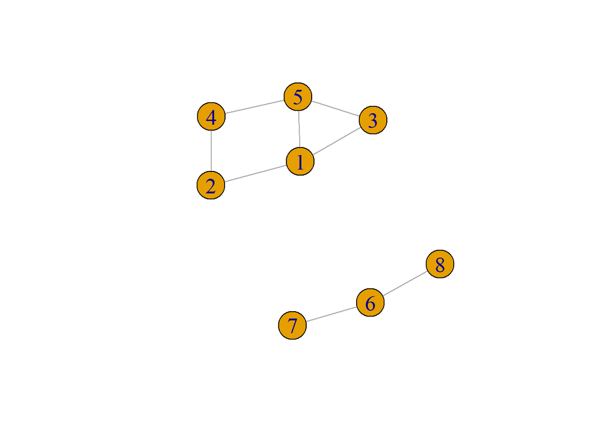

```r
grp2 <- graph_from_adjacency_matrix(out$outAdjmat, mode="undirected", diag=FALSE)
set.seed(1); plot(grp2, vertex.size=25, vertex.label.cex=1.5)
```